# Estudio inicial de un Data Frame

En R vienen cargados una serie de conjuntos de datos por defecto, basta escribir *data()* en la consola para verlos. En este ejercicio vamos a trabajar con datos de **iris** sobre un tipo específico de flores. Este conjunto de datos se suele usar como ejemplo de estudio.

El análisis exploratorio de datos o **EDA (Exploratory Data Analysis)** engloba un conjunto de técnicas para comprender de manera rápida la naturaleza de una colección de datos. Fue creado por el estadístico John Tukey y se basa principalmente en dos criterios: **estadísticas de resumen** y la **visualización** de datos.

# Estadística de los datos

Antes de comenzar debemos comprobar si el dataset está cargado correctamente.

| Sepal.Length | Sepal.Width | Petal.Length | Petal.Width | Species |
| --- | --- | --- | --- | --- |
| 5.1 | 3.5 | 1.4 | 0.2 | setosa |
| 4.9 | 3.0 | 1.4 | 0.2 | setosa |
| 4.7 | 3.2 | 1.3 | 0.2 | setosa |
| 4.6 | 3.1 | 1.5 | 0.2 | setosa |
| 5.0 | 3.6 | 1.4 | 0.2 | setosa |
| 5.4 | 3.9 | 1.7 | 0.4 | setosa |
| 4.6 | 3.4 | 1.4 | 0.3 | setosa |
| 5.0 | 3.4 | 1.5 | 0.2 | setosa |
| 4.4 | 2.9 | 1.4 | 0.2 | setosa |
| 4.9 | 3.1 | 1.5 | 0.1 | setosa |

[output cut: 140 more lines]

### Resumen de los datos

```r
sum(sapply(iris, is.numeric))
```

```
[1] 4
```

### Otras funciones importantes

```r
attributes(iris)
```

```
$names
[1] "Sepal.Length" "Sepal.Width"  "Petal.Length" "Petal.Width"  "Species"

$class
[1] "data.frame"

$row.names
  [1]   1   2   3   4   5   6   7   8   9  10  11  12  13  14  15  16  17  18  19  20  21  22  23  24  25  26  27  28  29
 [30]  30  31  32  33  34  35  36  37  38  39  40  41  42  43  44  45  46  47  48  49  50  51  52  53  54  55  56  57  58
 [59]  59  60  61  62  63  64  65  66  67  68  69  70  71  72  73  74  75  76  77  78  79  80  81  82  83  84  85  86  87
 [88]  88  89  90  91  92  93  94  95  96  97  98  99 100 101 102 103 104 105 106 107 108 109 110 111 112 113 114 115 116
[117] 117 118 119 120 121 122 123 124 125 126 127 128 129 130 131 132 133 134 135 136 137 138 139 140 141 142 143 144 145
[146] 146 147 148 149 150
```

### Estudio de una columna

Veamos cómo inspeccionar la columna *Sepal.Length*. Queremos ver los diez primeros elementos de dicha columna.

```r
matriz <- as.matrix(iris)
matriz[1:10,1]
```

```
 [1] "5.1" "4.9" "4.7" "4.6" "5.0" "5.4" "4.6" "5.0" "4.4" "4.9"
```

### Resumen estadístico de los datos

La función *summary* permite ver un resumen detallado de los datos. ¿Qué información aporta?

```r
# Función summary()
# numeric variables: minimum, maximum, mean, median, and
# -> the first (25%) and third (75%) quartiles
# -> categorical variables (factors): frequency of every level
```

### Resumen estadístico de columnas en concreto

Veamos cómo se calculan los momentos estadísticos más comunes de una columna en concreto, por ejemplo *Sepal.Length*.

La **frecuencia** de un valor de atributo es el número de veces que este es observado.

| Var1 | Freq |
| --- | --- |
| 4.3 | 1 |
| 4.4 | 3 |
| 4.5 | 1 |
| 4.6 | 4 |
| 4.7 | 2 |
| 4.8 | 5 |
| 4.9 | 6 |
| 5 | 10 |
| 5.1 | 9 |
| 5.2 | 4 |

[output cut: 25 more lines]

El rango de una variable:

```r
range(iris$Sepal.Length)
```

```
[1] 4.3 7.9
```

La **media**, **la mediana** y la **varianza** son medidas de tendencia central. Es decir, separan las observaciones en dos partes. Consulte Wikipedia para repasar su significado.

```r
# Media: función mean()
mean(iris$Sepal.Length)
```

```
[1] 5.843333
```

```r
# Mediana: función median()
median(iris$Sepal.Length)
```

```
[1] 5.8
```

```r
# Varianza: función var()
var(iris$Sepal.Length)
```

```
[1] 0.6856935
```

La **covarianza** se usa para comparar una variable respecto a otra. La covarianza cov(x, y) mide el grado de variacion lineal conjunta de un par de variables x, y, teniendo en cuenta que cov(x, x) = var (x).

```r
cov(iris$Sepal.Length,iris$Sepal.Width)
```

```
[1] -0.042434
```

Si dos variables son independientes entre si, su covarianza es cero. Para tener una medida de relación que no dependa de la escala de cada, variable, usamos la correlación lineal, con un valor que varía entre -1 a 1. Un valor cercano a 1 indica que mientras una variable crece la otra tambien lo hace en una proporción lineal. Un valor cercano a -1 indica una relacion inversa (una crece la otra decrece). Si la correlaci?n es cercana a cero tenemos independencia lineal. Eso no implica que no pueda haber una relacion no-lineal entre las variables.

```r
cor(iris$Sepal.Length,iris$Sepal.Width)
```

```
[1] -0.1175698
```

### Anexo: variables categóricas

Nota: Dado que en iris no hay dos variables categóricas, nos inventamos este ejemplo.

Para analizar la relación entre variables de naturaleza categórica usamos tablas de contingencia. La tabla se llena con las frecuencias marginales de todos los pares de valores entre dos variables categoricas. En R se crean usando el comando table que usabamos para frecuencias, pero entregandole dos vectores:

```r
# creamos datos para 10 individuos
edad=c(18,19,NA,18,24,17,22,15,22,25)
sexo=c(0,1,0,0,1,0,0,1,1,0)
estudios=c(1,2,0,1,3,2,3,1,2,3)

# Recodificamos como factores el sexo y el nivel de estudios, asignando las etiquetas adecuadas:
sexo=factor(sexo, levels=c(0,1),
                  labels=c("Hombre","Mujer"))
estudios=factor(estudios, levels=c(0,1,2,3),
                      labels=c("Sin estudios","Estudios Primarios",
                               "Estudios Secundarios","Estudios Superiores"))
datos<-cbind(edad, sexo, estudios)
datos
```

```
      edad sexo estudios
 [1,]   18    1        2
 [2,]   19    2        3
 [3,]   NA    1        1
 [4,]   18    1        2
 [5,]   24    2        4
 [6,]   17    1        3
 [7,]   22    1        4
 [8,]   15    2        2
 [9,]   22    2        3
[10,]   25    1        4
```

```r
table(estudios, sexo)
```

```
                      sexo
estudios               Hombre Mujer
  Sin estudios              1     0
  Estudios Primarios        2     1
  Estudios Secundarios      1     2
  Estudios Superiores       2     1
```

Igual que con la frecuencia, podemos trabajar con porcentajes

```r
prop.table(table(estudios, sexo))
```

```
                      sexo
estudios               Hombre Mujer
  Sin estudios            0.1   0.0
  Estudios Primarios      0.2   0.1
  Estudios Secundarios    0.1   0.2
  Estudios Superiores     0.2   0.1
```

Para las frecuencias relativas, en prop.table() incluimos un 1 si las queremos por filas, un 2 si por columnas, o nada si queremos las frecuencias relativas globales como hemos hecho:

```r
prop.table(table(estudios,sexo),1)
```

```
                      sexo
estudios                  Hombre     Mujer
  Sin estudios         1.0000000 0.0000000
  Estudios Primarios   0.6666667 0.3333333
  Estudios Secundarios 0.3333333 0.6666667
  Estudios Superiores  0.6666667 0.3333333
```

```r
prop.table(table(estudios,sexo),2)
```

```
                      sexo
estudios                  Hombre     Mujer
  Sin estudios         0.1666667 0.0000000
  Estudios Primarios   0.3333333 0.2500000
  Estudios Secundarios 0.1666667 0.5000000
  Estudios Superiores  0.3333333 0.2500000
```

# Visualización

La visualizacion de datos es la transformación de un dataset a un formato visual que permita a las personas identificar las características y las relaciones entre los elementos del dataset. La visualizacion permite que las personas reconozcan patrones o tendencias en base a su criterio en el dominio particular.

En R la funcion de visualización más frecuente es plot(). Es una funcion genérica cuyo resultado depende de la naturaleza de las variables usadas.

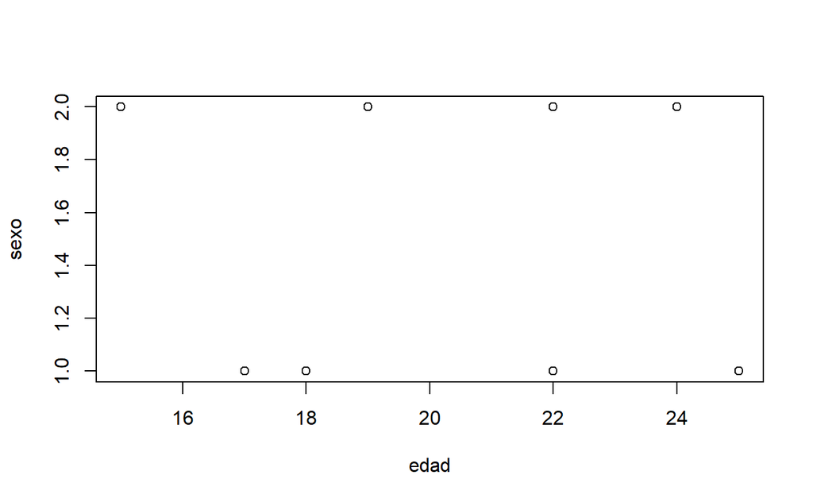

### Exploración visual de una varible en concreto.

Nos centramos en unas de las variables concreto, por ejemplo *Sepal.Length*.

Realicemos una serie de visualizacions más comunes.

- **Histogramas**

Muestran la distribución de los valores de una variable. Los valores de los elementos se dividen en contenedores (bins) y se crean graficos de barra por cada contenedor. La altura de cada barra indica el numero de elementos o frecuencia del contenedor. En R se crean con el comando hist.

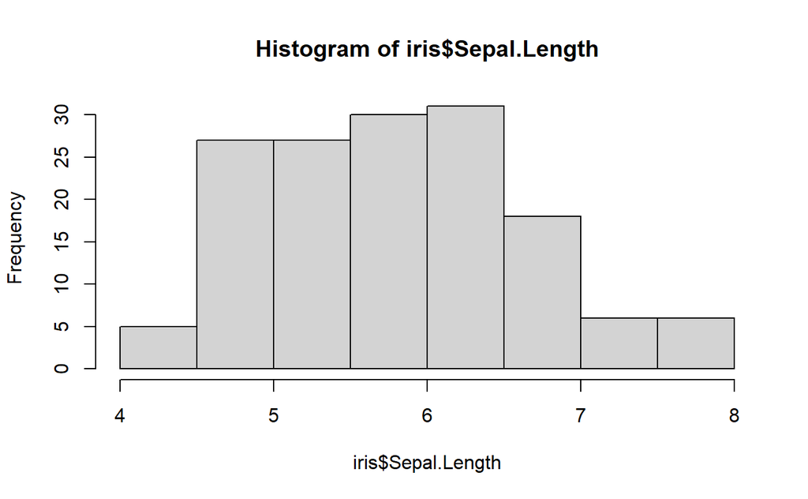

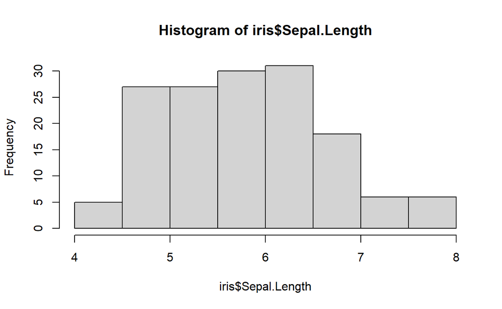

- **Densidad**

Otra forma de visualizar como se distribuyen los datos es estimando una densidad.

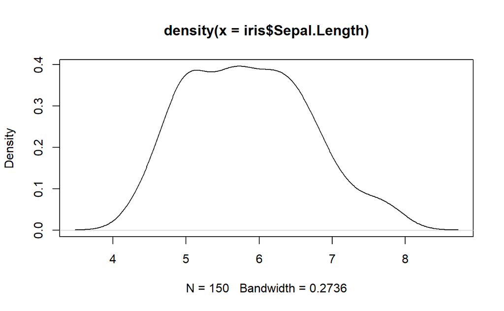

- **Gráficos de tarta**

Los graficos de tarta (pie charts) representan la frecuencia de los elementos en un círculo. Cada elemento tiene una participación proporcional a su frecuencia relativa. Se usan generalmente para variables categoricas.

[figure not shown]

- **Boxplots**

Los Boxplots o diagramas de caja se construyen a partir de los percentiles. Se construye una rectangulo usando entre el primer y el tercer cuartil (Q1 y Q3). El boxplot nos entrega información sobre la simetría de la distribución de los datos. Si la mediana no esta en el centro del rectángulo, la distribución no es simétrica. Son útiles para ver la presencia de outliers.

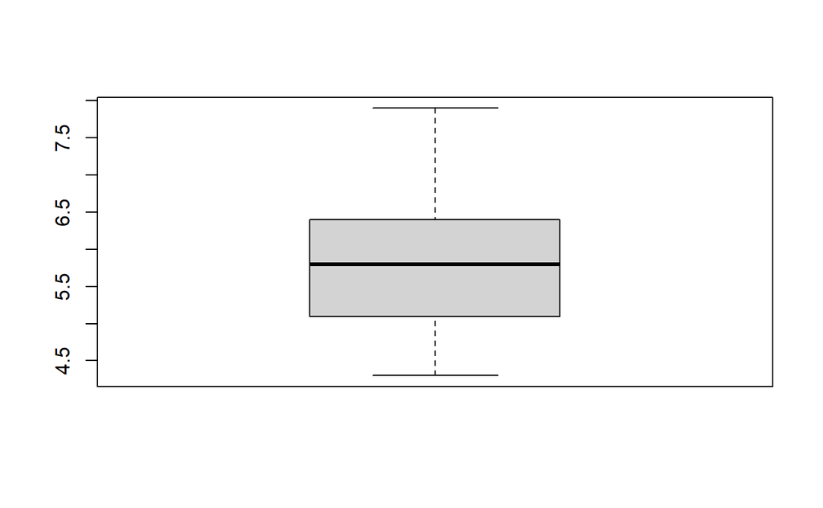

- **Diagrama de barras**

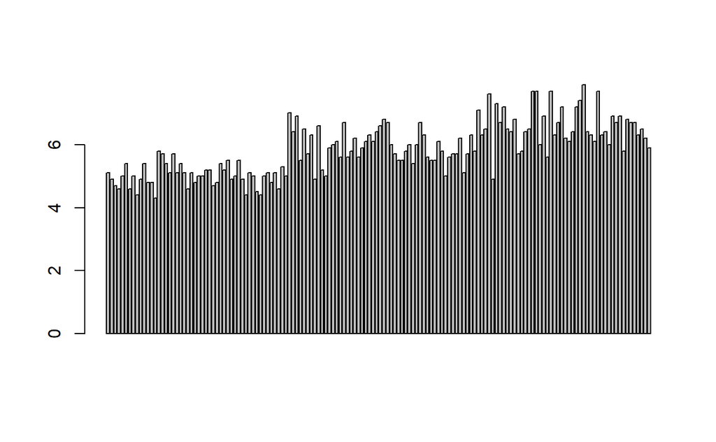

### Exploración visual de varias variables

Realicemos una serie de visualizaciones teniendo en cuenta varias variables.

```r
# Matriz de covarianzas
cov(iris[, 1:4])
```

```
             Sepal.Length Sepal.Width Petal.Length Petal.Width
Sepal.Length    0.6856935  -0.0424340    1.2743154   0.5162707
Sepal.Width    -0.0424340   0.1899794   -0.3296564  -0.1216394
Petal.Length    1.2743154  -0.3296564    3.1162779   1.2956094
Petal.Width     0.5162707  -0.1216394    1.2956094   0.5810063
```

```r
# Matriz de correlaciones
cor(iris[, 1:4])
```

```
             Sepal.Length Sepal.Width Petal.Length Petal.Width
Sepal.Length    1.0000000  -0.1175698    0.8717538   0.8179411
Sepal.Width    -0.1175698   1.0000000   -0.4284401  -0.3661259
Petal.Length    0.8717538  -0.4284401    1.0000000   0.9628654
Petal.Width     0.8179411  -0.3661259    0.9628654   1.0000000
```